# ManyClasses 1 Simulated Analysis

```r
library(runjags)
library(tidyr)
library(dplyr)
library(ggplot2)
library(ggstance)
library(stringr)
library(tibble)
library(forcats)
library(purrr)
library(tidybayes)
library(readr)
```

Set seed for reproducibility

```r
set.seed(47401)
```

# Loading in data

```r
student.data <- read_csv('data/manyclasses_student_outcomes_and_moderators.csv', col_types = "ddfddfffddddddd")

institutions.data <- read_csv('data/many_classes_institutions.csv', col_types = "cdddndddddd") %>% select(-Institution)

classes.data <- read_csv('data/many_classes_classes.csv', col_types = "ddffdddfdfddfdddfddffddddfdf")
classes.data <- classes.data %>% arrange(manyclasses_course_id) %>%
  mutate(IncentiveCondition = factor(IncentiveCondition, levels=c("No", "Yes"))) %>%
  left_join(institutions.data, by=c("manyclasses_institution_id"))

student.class.data <- student.data %>%
  left_join(classes.data, by=c("manyclasses_course_id", "manyclasses_institution_id"))
```

# Treatment characteristic descriptives

The mean number of items on quiz assignments

```r
classes.data %>%
  mutate(items_per_quiz = Quiz_CumulativeNumberofQuizQuestions / Class_NumberOfTreatmentQuizzes) %>%
  summarize(M_items_per_quiz = mean(items_per_quiz), SD_items_per_quiz = sd(items_per_quiz))
```

| M_items_per_quiz | SD_items_per_quiz |
| --- | --- |
| 10.14759 | 6.998599 |

```r
NA
```

Quiz scores

```r
classes.data %>%
  summarize(M = mean(Quiz_Difficulty_AveragePercentCorrect), SD = sd(Quiz_Difficulty_AveragePercentCorrect))
```

| M | SD |
| --- | --- |
| 0.8076342 | 0.09446071 |

```r
NA
```

Retrieval-based quiz items

```r
classes.data %>%
  summarize(M = mean(Quiz_ProportionOfRetrievalBasedQuizItems), SD = sd(Quiz_ProportionOfRetrievalBasedQuizItems), min=min(Quiz_ProportionOfRetrievalBasedQuizItems), max=max(Quiz_ProportionOfRetrievalBasedQuizItems))
```

| M | SD | min | max |
| --- | --- | --- | --- |
| 0.06763158 | 0.2359963 | 0 | 1 |

```r
NA
```

Type of feedback content

```r
table(classes.data$Quiz_TypeOfFeedbackContent)
```

```
   Explanation Correct answer   Verification
            16             17              5
```

```r
# proportion of explanation-based feedback
16 / 38
```

```
[1] 0.4210526
```

Delay between immediate and delayed

```r
classes.data %>%
  summarize(M = mean(Quiz_NumberOfDayDelay_BetweenDueDateandDelayedFeedback), SD = sd(Quiz_NumberOfDayDelay_BetweenDueDateandDelayedFeedback), min=min(Quiz_NumberOfDayDelay_BetweenDueDateandDelayedFeedback), max=max(Quiz_NumberOfDayDelay_BetweenDueDateandDelayedFeedback))
```

| M | SD | min | max |
| --- | --- | --- | --- |
| 2.578947 | 1.130214 | 1 | 5 |

```r
NA
```

Student’s viewed incentivized feedback

```r
student.class.data %>% filter(IncentiveCondition == "Yes") %>% pull(student_accessedAllDelayedFeedback) %>% table()
```

```
.
 no yes
806 568
```

# Assessment Characteristics

Number of questions

```r
classes.data %>%
  summarize(M = mean(Exam_NumberOfQuestionsMappedToQuizzes), SD = sd(Exam_NumberOfQuestionsMappedToQuizzes))
```

| M | SD |
| --- | --- |
| 25.38947 | 23.34713 |

```r
NA
```

Exam performance

```r
classes.data %>%
  summarize(M = mean(Exam_Difficulty_AveragePercentCorrect), SD = sd(Exam_Difficulty_AveragePercentCorrect))
```

| M | SD |
| --- | --- |
| 0.7928947 | 0.09279177 |

```r
NA
```

# Model 1: Overall Effect of Feedback and Incentives

This model estimates the distribution of delta-z scores in each classroom, as well as the distribution of classroom averages in each incentive condition. The JAGS model code is available in `basic-model-jags.txt`. The model is run in a separate script to take advantage of high-performance computing resources. The output from that run is loaded here.

## Loading the results of the overall model

```r
model.1.result <- readRDS('data/model-runs/overall.rds')
```

## Class-level effect of feedback and incentive

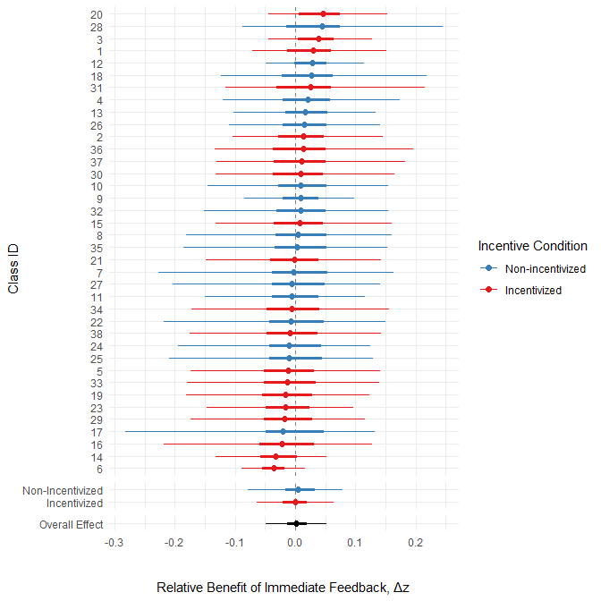

```r
tidy.model.1.summary <- model.1.result %>%
  gather_draws(mu.class[manyclasses_course_id], mu.condition.effect[incentive], mu.condition.average) %>%
  median_hdci(.width = c(0.5,0.95)) %>%
  left_join(classes.data, by=c("manyclasses_course_id")) %>%
  mutate(IncentiveCondition = as.character(IncentiveCondition)) %>%
  mutate(incentive = case_when(
    .variable == "mu.condition.average" ~ "z",
    incentive == 1 ~ "No",
    incentive == 2 ~ "Yes",
    is.na(incentive) ~ IncentiveCondition
  )) %>%
  mutate(y.label = case_when(
    .variable == 'mu.condition.average' ~ "Overall Effect",
    .variable == 'mu.condition.effect' & incentive == "No" ~ "Non-Incentivized",
    .variable == 'mu.condition.effect' & incentive == "Yes" ~ "Incentivized",
    is.na(manyclasses_course_id) ~ incentive,
    !is.na(manyclasses_course_id) ~ as.character(manyclasses_course_id)
  )) %>%
  ungroup() %>%
  mutate(.variable = factor(.variable, levels=c('mu.class', 'mu.condition.effect', 'mu.condition.average'))) %>%
  mutate(y.label = factor(y.label)) %>%
  mutate(y.label = fct_reorder(y.label, .value))

fig.1 <- ggplot(tidy.model.1.summary, aes(x=.value, y=y.label, xmin=.lower, xmax=.upper, color=incentive))+
  geom_vline(xintercept=0, linetype='dashed', color="grey50") +
  geom_pointintervalh(show_point=F) +
  geom_point(size=2)+
  labs(y="Class ID", x="\nRelative Benefit of Immediate Feedback, \u0394z")+
  facet_grid(.variable~., scales = 'free', space='free')+
  scale_color_manual(name="Incentive Condition",
                     breaks=c("No", "Yes"),
                     labels=c("Non-incentivized", "Incentivized", NULL),
                     values=c("#377eb8", "#e41a1c", "Black"))+
  theme_minimal()+
  theme(
    strip.background = element_blank(),
    strip.text = element_blank(),
    axis.title.x = element_text(size = 11)
  )

ggsave('figs/class-level-effects.png', plot=fig.1, device="png")
fig.1
```

Summary stats on condition-level and global effects.

```r
model.1.result %>%
  gather_draws(mu.condition.effect[incentive], sigma.condition.effect[incentive], mu.condition.diff, mu.condition.average) %>%
  median_hdci(.width = c(0.95))
```

| incentive | .variable | .value | .lower | .upper | .width | .point | .interval |
| --- | --- | --- | --- | --- | --- | --- | --- |
| 1 | mu.condition.effect | 0.004398370 | -0.078439300 | 0.0781525 | 0.95 | median | hdci |
| 1 | sigma.condition.effect | 0.060173600 | 0.000402812 | 0.1634370 | 0.95 | median | hdci |
| 2 | mu.condition.effect | 0.000416235 | -0.063948900 | 0.0634323 | 0.95 | median | hdci |
| 2 | sigma.condition.effect | 0.064206750 | 0.006102140 | 0.1389750 | 0.95 | median | hdci |
| NA | mu.condition.average | 0.002036030 | -0.049011700 | 0.0513638 | 0.95 | median | hdci |
| NA | mu.condition.diff | 0.003077375 | -0.098435900 | 0.1033600 | 0.95 | median | hdci |

Plot of Confidence Intervals without model estimation, to illustrate degree of shrinkage and what would happen without shrinkage in inferences.

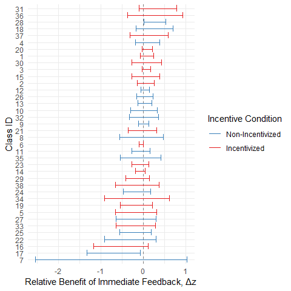

```r
no.shrink.data <- student.class.data %>%
  group_by(manyclasses_course_id) %>%
  summarise(m = mean(outcome), se=sd(outcome)/sqrt(n()), n=n(), p=t.test(outcome, mu=0)$p.value, ci.low = t.test(outcome, mu=0)$conf.int[1], ci.high = t.test(outcome, mu=0)$conf.int[2]) %>%
  left_join(classes.data, by="manyclasses_course_id") %>%
  mutate(manyclasses_course_id = factor(manyclasses_course_id)) %>%
  mutate(manyclasses_course_id = fct_reorder(manyclasses_course_id, m))

no.shrinkage.plot <- ggplot(no.shrink.data, aes(x=m, xmin=ci.low, xmax = ci.high, y=manyclasses_course_id, color=IncentiveCondition)) +
  geom_vline(xintercept=0, linetype='dashed', color="grey50") +
  geom_errorbarh()+
  labs(x="Relative Benefit of Immediate Feedback, \u0394z", y="Class ID", color="Incentive Condition")+
  scale_color_manual(values=c("#377eb8", "#e41a1c"), labels=c("Non-Incentivized", "Incentivized"))+
  theme_minimal()+
  theme(
    strip.background = element_blank(),
    strip.text = element_blank(),
    axis.title.x = element_text(size = 11)
  )

ggsave('figs/no-shrinkage-class-effects.png', no.shrinkage.plot, device="png")

no.shrinkage.plot
```

## Heterogeneity Analysis

We quantify heterogeneity at the classroom level by looking at the model’s estimate of the standard deviation of classroom-level means.

```r
model.1.h.tidy <- model.1.result %>% gather_draws(sigma.condition.effect[incentive])

model.1.h.tidy %>% median_hdci(.width = c(0.95))
```

| incentive | .variable | .value | .lower | .upper | .width | .point | .interval |
| --- | --- | --- | --- | --- | --- | --- | --- |
| 1 | sigma.condition.effect | 0.06017360 | 0.000402812 | 0.163437 | 0.95 | median | hdci |
| 2 | sigma.condition.effect | 0.06420675 | 0.006102140 | 0.138975 | 0.95 | median | hdci |

We can visualize the distribution of classroom-level means according to the model.

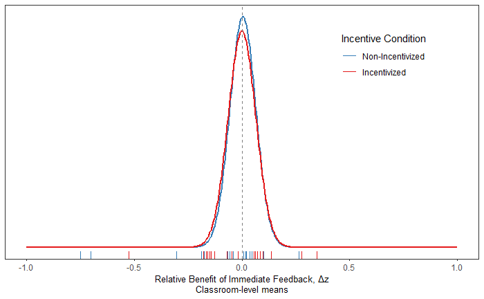

```r
#class.means <- student.class.data %>% group_by(manyclasses_course_id) %>% summarize(M=mean(outcome)) %>% pull(M)

condition.summary <- model.1.result %>%
  spread_draws(mu.condition.effect[incentive], sigma.condition.effect[incentive]) %>%
  median_hdci(.width=c(0.95))

class.observed.means.data= student.class.data %>% group_by(manyclasses_course_id, IncentiveCondition) %>% summarize(M=mean(outcome))

heterogeneity.plot <- ggplot(class.observed.means.data, aes(x=M, color=IncentiveCondition))+
  geom_rug()+
  stat_function(
    data=data.frame(x=-1:1),
    mapping=aes(x=x, color=NULL),
    geom="line",
    color="#377eb8",
    size=1,
    fun=dnorm,
    n=501,
    args=list(
      mean = (condition.summary %>% filter(incentive==1) %>% pull(mu.condition.effect)),
      sd = (condition.summary %>% filter(incentive==1) %>% pull(sigma.condition.effect))
    )
  ) +
  stat_function(
    data=data.frame(x=-1:1),
    mapping=aes(x=x, color=NULL),
    geom="line",
    color="#e41a1c",
    size=1,
    fun=dnorm,
    n=501,
    args=list(
      mean = (condition.summary %>% filter(incentive==2) %>% pull(mu.condition.effect)),
      sd = (condition.summary %>% filter(incentive==2) %>% pull(sigma.condition.effect))
    )
  ) +
  scale_color_manual(values=c("#377eb8", "#e41a1c"), labels=c("Non-Incentivized", "Incentivized"))+
  scale_y_continuous(breaks=NULL)+
  geom_vline(xintercept = 0, color="grey50", linetype="dashed")+
  labs(x="Relative Benefit of Immediate Feedback, \u0394z\nClassroom-level means", y=NULL, color="Incentive Condition")+
  theme_bw()+
  theme(panel.grid = element_blank(),
        axis.title.x = element_text(size=10),
        legend.position = c(0.8,0.8))

ggsave('figs/heterogeneity-plot.png', heterogeneity.plot, device = "png", width=6, height=6)

heterogeneity.plot
```

## Chain Info

Summarize convergence and sampling metrics from the chains for Model 1.

Number of samples per chain:

```r
model.1.result$sample
```

```
[1] 3000
```

Worst psrf:

```r
max(model.1.result$summaries[,'psrf'])
```

```
[1] 1.002704
```

Smallest effective sample size:

```r
min(model.1.result$summaries[,'SSeff'])
```

```
[1] 13388
```

# Moderator Analysis

Generating a list of moderators based on data columns

```r
class.level.moderators <- colnames(classes.data)[3:length(colnames(classes.data))]
class.level.moderators <- class.level.moderators[class.level.moderators != "IncentiveCondition"]

student.level.moderators <- colnames(student.data)[5:length(colnames(student.data))]
```

## R<sup>2</sup> estimates

Load in the estimates from `extract-r2-data-from-model-runs.R`. Estimation extraction was moved to a different script because it is memory-intensive to load the chains necessary to run these calculations.

```r
r2.moderator.estimates <- read_csv('data/generated/moderator-r2-summaries.csv', col_types = 'dfddddffff')
```

Create pretty names for factors

```r
r2.moderator.estimates <- r2.moderator.estimates %>%
  rowwise() %>%
  mutate(moderator.level = str_to_title(str_split(moderator, '_')[[1]][1])) %>%
  mutate(pretty.names = case_when(
    moderator == "Class_ConsentRate" ~ "ᴱConsent Rate",
    moderator == "Class_Discipline" ~ "Discipline (STEM vs. Non-STEM)",
    moderator == "Class_Format" ~ "Format (In-Person, Hybrid, Online)",
    moderator == "Class_Level" ~ "Class Level",
    moderator == "Class_NumberOfExams" ~ "Number of Exams",
    moderator == "Class_NumberOfTreatmentQuizzes" ~ "Number of Treatment Quizzes",
    moderator == "Class_ProportionLecture" ~ "Proportion Lecture",
    moderator == "Class_QuizzesCombinedInOutcomeScores" ~ "ᴱQuizzes Combined in Outcome Scores",
    moderator == "Class_Size" ~ "Size",
    moderator == "Exam_AverageDaysBetweenQuizDueDateandExam" ~ "Avg. Days Between Quiz and Exam",
    moderator == "Exam_Difficulty_AveragePercentCorrect" ~ "Difficulty: Avg. % Correct",
    moderator == "Exam_MappingToQuizzes_ExamSameVSNot" ~ "Question Type Same As Quizzes",
    moderator == "Exam_NumberOfQuestionsMappedToQuizzes" ~ "Number of Questions Mapped to Quizzes",
    moderator == "Exam_ProportionOfRetrievalBasedExamItems" ~ "% Retrieval Based Exam Items",
    moderator == "Exam_Type_InClassVSTakeHome" ~ "Exam Type (In Class vs. Take Home)",
    moderator == "Exam_Value_ProportionOfClassPoints" ~ "% Class Points",
    moderator == "Institution_AdmissionRate" ~ "Admission Rate",
    moderator == "Institution_AverageAnnualCostofAttendance" ~ "Avg. Annual Cost",
    moderator == "Institution_GraduationRate" ~ "Graduation Rate",
    moderator == "Institution_PercentofFullTimeStudents" ~ "% Full Time Students",
    moderator == "Institution_PercentPartTimeFaculty" ~ "% Full Time Faculty",
    moderator == "Institution_PercentReceivingFederalStudentLoans" ~ "% Students Receiving Fed. Loans",
    moderator == "Institution_PercentStudentsReceivingIncomeBasedPellGrants" ~ "% Students Receiving Pell Grants",
    moderator == "Institution_PercentStudentsReturningAfterFirstYear" ~ "% Students Returning After 1st Year",
    moderator == "Institution_PercentWhite" ~ "% White Students",
    moderator == "Quiz_CumulativeNumberofQuizQuestions" ~ "Cumulative Number of Questions",
    moderator == "Quiz_NumberOfDayDelay_BetweenDueDateandDelayedFeedback" ~ "Delay Length for Delayed Feedback",
    moderator == "Quiz_ProportionOfRetrievalBasedQuizItems" ~ "% of Retrieval Based Items",
    moderator == "Quiz_QuestionPresentation_OneAtaTimeVSAllatOnce" ~ "Simultaneous vs. Sequential Questions",
    moderator == "Quiz_TimeConstraint" ~ "Time Constraint",
    moderator == "Quiz_TypeOfFeedbackContent" ~ "Feedback Content Type",
    moderator == "Quiz_Value_ProportionOfClassPoints" ~ "% of Class Points",
    moderator == "Quiz_FollowUpValue_ProportionOfClassPoints" ~ "Follow Up % of Class Points",
    moderator == "Quiz_Difficulty_AveragePercentCorrect" ~ "Avg. % Correct",
    moderator == "student_accessedAllDelayedFeedback" ~ "Accessed All Delayed Feedback",
    moderator == "student_accessedAllImmediateFeedback" ~ "Accessed All Immediate FeedbackNo",
    moderator == "student_accessedAllTreatmentQuizzes" ~ "Accessed All Treatment Quizzes",
    moderator == "student_avgTimeSpentOnTreatmentQuizzes" ~ "ᴱAvg. Time Spent on Treatment Quizzes",
    moderator == "student_avgTimeSpentViewingFeedback" ~ "ᴱAvg. Time Spent Viewing Feedback",
    moderator == "student_cumulativeGrade" ~ "Cumulative Grade",
    moderator == "student_daysFeedbackAfterSubmission" ~ "Days Feedback After Submission",
    moderator == "student_daysSubmittedBeforeDueDate" ~ "Days Submitted Before Due Date",
    moderator == "student_nbrOfQuizzesWithFeedbackView" ~ "ᴱNumber of Quizzes With Viewed Feedback",
    moderator == "student_timeSpentOnTreatmentQuizzes" ~ "Time Spent on Treatment Quizzes",
    moderator == "student_timeSpentViewingFeedback" ~ "Time Spent Viewing Feedback"
  ))
```

Plot the R<sup>2</sup> of the models with class-level moderators

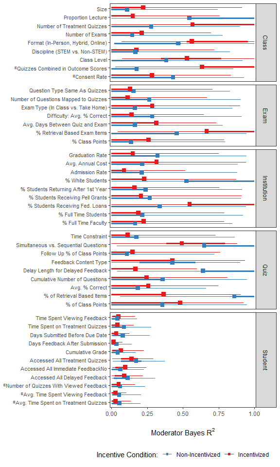

```r
moderator.r2.plot <- ggplot(r2.moderator.estimates, aes(x=.value, xmin=.lower, xmax=.upper, y=pretty.names, color=factor(incentive)))+
  geom_pointintervalh(shape=15, position = position_dodgev(height=0.5)) +
  labs(y=NULL, x=bquote('Moderator Bayes'~R^2), color="Incentive Condition:")+
  scale_color_manual(values=c("#377eb8", "#e41a1c"), labels=c("Non-Incentivized", "Incentivized"))+
  facet_grid(moderator.level~., scales="free_y", space="free" )+
  scale_x_continuous(expand = c(0.005,0.005))+
  theme_bw()+
  theme(panel.grid.major.x = element_blank(),
        panel.grid.major.y = element_blank(),
        panel.grid.minor.x = element_blank(),
        legend.position = "bottom",
        axis.text.y = element_text(size=8,angle=0))

ggsave('figs/moderator-summary-plot-r2.png', plot=moderator.r2.plot, device="png", height=10, width=6)

moderator.r2.plot
```

## Moderator Coefficients

The R<sup>2</sup> analysis was less diagnostic than we expected, so here we make a similar plot looking at the credible intervals for the coefficients of each moderator. We had initially wanted a single value per moderator regardless of whether the moderator was continuous or discrete, but instead we’ve settled for plotting the coefficients separately for each level of the discrete moderators.

```r
moderator.plot.data <- read_csv('data/generated/moderator-summaries.csv')
```

```r
moderator.plot.data <- moderator.plot.data %>%
  rowwise() %>%
  mutate(level.name = str_to_title(str_split(moderator, "_")[[1]][1])) %>%
  mutate(moderator.expanded = if_else(moderator.type=="Discrete", paste0(moderator,".",factor.level), moderator)) %>%
  mutate(pretty.names = case_when(
    moderator.expanded == "Class_ConsentRate" ~ "ᴱConsent Rate",
    moderator.expanded == "Class_Discipline.1" ~ "Discipline: Non-STEM",
    moderator.expanded == "Class_Discipline.2" ~ "Discipline: STEM",
    moderator.expanded == "Class_Format.1" ~ "Format: In-Class",
    moderator.expanded == "Class_Format.2" ~ "Format: Online",
    moderator.expanded == "Class_Format.3" ~ "Format: Hybrid",
    moderator.expanded == "Class_Level.1" ~ "Level: Intro",
    moderator.expanded == "Class_Level.2" ~ "Level: Intermediate",
    moderator.expanded == "Class_Level.3" ~ "Level: Advanced",
    moderator.expanded == "Class_NumberOfExams" ~ "Number of Exams",
    moderator.expanded == "Class_NumberOfTreatmentQuizzes" ~ "Number of Treatment Quizzes",
    moderator.expanded == "Class_ProportionLecture" ~ "Proportion Lecture",
    moderator.expanded == "Class_QuizzesCombinedInOutcomeScores.1" ~ "ᴱQuizzes Combined in Outcome Scores: No",
    moderator.expanded == "Class_QuizzesCombinedInOutcomeScores.2" ~ "ᴱQuizzes Combined in Outcome Scores: Yes",
    moderator.expanded == "Class_Size" ~ "Size",
    moderator.expanded == "Exam_AverageDaysBetweenQuizDueDateandExam" ~ "Avg. Days Between Quiz and Exam",
    moderator.expanded == "Exam_Difficulty_AveragePercentCorrect" ~ "Difficulty: Avg. % Correct",
    moderator.expanded == "Exam_MappingToQuizzes_ExamSameVSNot.1" ~ "Question Type Same As Quizzes: No",
    moderator.expanded == "Exam_MappingToQuizzes_ExamSameVSNot.2" ~ "Question Type Same As Quizzes: Yes",
    moderator.expanded == "Exam_NumberOfQuestionsMappedToQuizzes" ~ "Number of Questions Mapped to Quizzes",
    moderator.expanded == "Exam_ProportionOfRetrievalBasedExamItems" ~ "% Retrieval Based Exam Items",
    moderator.expanded == "Exam_Type_InClassVSTakeHome.1" ~ "Exam Type: In Class",
    moderator.expanded == "Exam_Type_InClassVSTakeHome.2" ~ "Exam Type: Take Home",
    moderator.expanded == "Exam_Value_ProportionOfClassPoints" ~ "% Class Points",
    moderator.expanded == "Institution_AdmissionRate" ~ "Admission Rate",
    moderator.expanded == "Institution_AverageAnnualCostofAttendance" ~ "Avg. Annual Cost",
    moderator.expanded == "Institution_GraduationRate" ~ "Graduation Rate",
    moderator.expanded == "Institution_PercentofFullTimeStudents" ~ "% Full Time Students",
    moderator.expanded == "Institution_PercentPartTimeFaculty" ~ "% Full Time Faculty",
    moderator.expanded == "Institution_PercentReceivingFederalStudentLoans" ~ "% Students Receiving Fed. Loans",
    moderator.expanded == "Institution_PercentStudentsReceivingIncomeBasedPellGrants" ~ "% Students Receiving Pell Grants",
    moderator.expanded == "Institution_PercentStudentsReturningAfterFirstYear" ~ "% Students Returning After 1st Year",
    moderator.expanded == "Institution_PercentWhite" ~ "% White Students",
    moderator.expanded == "Quiz_CumulativeNumberofQuizQuestions" ~ "Cumulative Number of Questions",
    moderator.expanded == "Quiz_NumberOfDayDelay_BetweenDueDateandDelayedFeedback" ~ "Delay Length for Delayed Feedback",
    moderator.expanded == "Quiz_ProportionOfRetrievalBasedQuizItems" ~ "% of Retrieval Based Items",
    moderator.expanded == "Quiz_QuestionPresentation_OneAtaTimeVSAllatOnce.1" ~ "Question Presentation: Simultaneous",
    moderator.expanded == "Quiz_QuestionPresentation_OneAtaTimeVSAllatOnce.2" ~ "Question Presentation: Sequential",
    moderator.expanded == "Quiz_TimeConstraint.1" ~ "Time Constraint: Yes",
    moderator.expanded == "Quiz_TimeConstraint.2" ~ "Time Constraint: No",
    moderator.expanded == "Quiz_TypeOfFeedbackContent.1" ~ "Feedback Content: Explanation",
    moderator.expanded == "Quiz_TypeOfFeedbackContent.2" ~ "Feedback Content: Correct Ans.",
    moderator.expanded == "Quiz_TypeOfFeedbackContent.3" ~ "Feedback Content: Verification",
    moderator.expanded == "Quiz_Value_ProportionOfClassPoints" ~ "% of Class Points",
    moderator.expanded == "Quiz_FollowUpValue_ProportionOfClassPoints" ~ "Follow Up % of Class Points",
    moderator.expanded == "Quiz_Difficulty_AveragePercentCorrect" ~ "Avg. % Correct",
    moderator.expanded == "student_accessedAllDelayedFeedback.1" ~ "Accessed All Delayed Feedback: No",
    moderator.expanded == "student_accessedAllDelayedFeedback.2" ~ "Accessed All Delayed Feedback: Yes",
    moderator.expanded == "student_accessedAllImmediateFeedback.1" ~ "Accessed All Immediate Feedback: No",
    moderator.expanded == "student_accessedAllImmediateFeedback.2" ~ "Accessed All Immediate Feedback: Yes",
    moderator.expanded == "student_accessedAllTreatmentQuizzes.1" ~ "Accessed All Treatment Quizzes: No",
    moderator.expanded == "student_accessedAllTreatmentQuizzes.2" ~ "Accessed All Treatment Quizzes: Yes",
    moderator.expanded == "student_avgTimeSpentOnTreatmentQuizzes" ~ "ᴱAvg. Time Spent on Treatment Quizzes",
    moderator.expanded == "student_avgTimeSpentViewingFeedback" ~ "ᴱAvg. Time Spent Viewing Feedback",
    moderator.expanded == "student_cumulativeGrade" ~ "Cumulative Grade",
    moderator.expanded == "student_daysFeedbackAfterSubmission" ~ "Days Feedback After Submission",
    moderator.expanded == "student_daysSubmittedBeforeDueDate" ~ "Days Submitted Before Due Date",
    moderator.expanded == "student_nbrOfQuizzesWithFeedbackView" ~ "ᴱNumber of Quizzes With Viewed Feedback",
    moderator.expanded == "student_timeSpentOnTreatmentQuizzes" ~ "Time Spent on Treatment Quizzes",
    moderator.expanded == "student_timeSpentViewingFeedback" ~ "Time Spent Viewing Feedback"
  ))
```

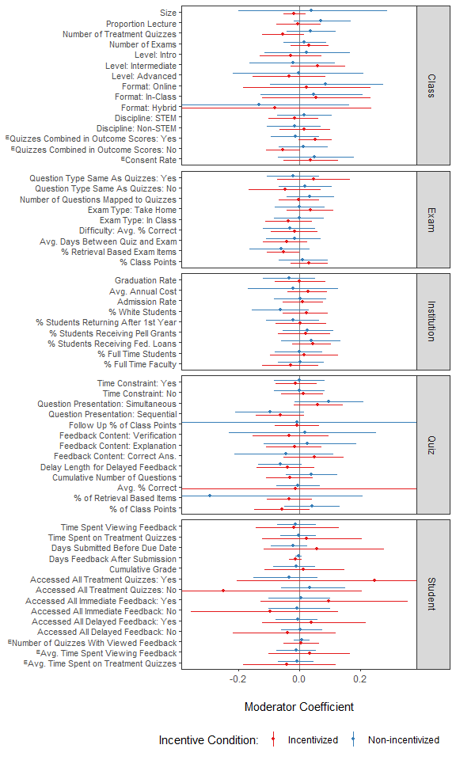

```r
moderator.summary.plot <- ggplot(moderator.plot.data,
       aes(y=pretty.names, xmin=low.95, x=median, xmax=upper.95, color=incentive, group=interaction(incentive, factor.level)))+
  geom_vline(xintercept = 0, color="grey50")+
  geom_pointrange(position = position_dodge2(width=0.6), size=0.2)+
  scale_color_brewer(type="qual", palette = "Set1")+
  facet_grid(level.name~., scales="free_y", space="free" )+
  labs(x="Moderator Coefficient", y=NULL, color="Incentive Condition:")+
  coord_cartesian(xlim=c(-0.35, 0.35))+
  theme_bw()+
  theme(panel.grid.major.x = element_blank(),
        panel.grid.major.y = element_blank(),
        panel.grid.minor.x = element_blank(),
        legend.position = "bottom",
        axis.text.y = element_text(size=8,angle=0))

ggsave('figs/moderator-summary-plot.png', plot=moderator.summary.plot, device="png", height=10, width=6)

moderator.summary.plot
```

## Individual Moderator Plots

These functions generate a plot for a single moderator. The plots include uncertainty estimates of both moderator effects and class-level estimates.

### Classroom-level plotting function

```r
plot.class.level.moderator <- function(moderator.name, moderator.pretty.name=NA, jitter=0){

  # Load model run
  moderator.model.result <- readRDS(paste0("data/model-runs/moderator-class-",moderator.name,".rds"))

  # Grab CIs for means of each class, and merge with the moderator value
  model.class.estimates <- moderator.model.result %>%
    gather_draws(mu.class[manyclasses_course_id]) %>%
    median_hdci(.width = c(0.95)) %>%
    left_join(classes.data %>% select(manyclasses_course_id, IncentiveCondition, !!sym(moderator.name)), by="manyclasses_course_id")


  # Check if the moderator is discrete or continuous.
  is.continuous.moderator <- is.numeric(classes.data[[moderator.name]])

  # For Continuous Moderators
  if(is.continuous.moderator){

    # Get the moderator effect estimates from the model
    model.moderator.posterior <- moderator.model.result %>%
      spread_draws(mu.condition.effect[incentive], moderator.effect[incentive]) %>%
      mutate(slope = moderator.effect / sd(classes.data[[moderator.name]])) %>%
      mutate(intercept = mu.condition.effect - moderator.effect * mean(classes.data[[moderator.name]])/sd(classes.data[[moderator.name]])) %>%
      ungroup() %>%
      mutate(incentive = factor(incentive, labels=c("No", "Yes"))) %>%
      group_by(incentive)

    model.moderator.hdci <- model.moderator.posterior %>% median_hdci()

    model.moderator.estimates <- model.moderator.posterior %>% sample_n(40)

    p <- ggplot(model.class.estimates, aes(x=!!sym(moderator.name), y=.value, ymin=.lower, ymax=.upper, color=IncentiveCondition)) +
      geom_pointinterval(alpha=0.5, position=position_jitter(width=jitter))+
      geom_abline(data=model.moderator.estimates,
                  aes(intercept = intercept, slope=slope, color=factor(incentive)), alpha=0.1, show.legend = FALSE) +
      labs(
        x=ifelse(is.na(moderator.pretty.name), moderator.name, moderator.pretty.name),
        y="Relative benefit of immediate feedback",
        caption=paste0(
          "Incentivized Feedback 95% HDI: ",
          paste(model.moderator.hdci %>% filter(incentive == "Yes") %>% pull(moderator.effect.lower) %>% round(3),
                collapse= " "),
          " to ",
          paste(model.moderator.hdci %>% filter(incentive == "Yes") %>% pull(moderator.effect.upper) %>% round(3),
                collapse = " "),
          "\n",
          "Non-incentivized Feedback 95% HDI: ",
          paste(model.moderator.hdci %>% filter(incentive == "No") %>% pull(moderator.effect.lower) %>% round(3),
                collapse = " "),
          " to ",
          paste(model.moderator.hdci %>% filter(incentive == "No") %>% pull(moderator.effect.upper) %>% round(3),
                collapse = " ")
        )
      ) +
      scale_color_manual(values=c("#377eb8", "#e41a1c"), name="Incentive Condition") +
      theme_bw() +
      theme(panel.grid=element_blank(),
            plot.caption=element_text(hjust=1))

  }

  # For Discrete Moderators
  if(!is.continuous.moderator){

    model.moderator.posterior <- moderator.model.results %>%
      spread_draws(mu.condition.effect[incentive], moderator.effect[incentive, moderator.level]) %>%
      ungroup() %>%
      mutate(incentive = factor(incentive, labels=c("No", "Yes"))) %>%
      mutate(!!moderator.name := factor(moderator.level, labels=levels(classes.data[[moderator.name]]))) %>%
      group_by(incentive, !!sym(moderator.name))

    model.moderator.hdci <- model.moderator.posterior %>% median_hdci()

    model.moderator.estimates <- model.moderator.posterior %>% sample_n(40)

    p <- ggplot(model.class.estimates, aes(x=!!sym(moderator.name), y=.value, ymin=.lower, ymax=.upper, color=IncentiveCondition)) +
    geom_pointinterval(position=position_jitterdodge(), alpha=0.2) +
    geom_crossbar(data=model.moderator.estimates, aes(x=!!sym(moderator.name), y = mu.condition.effect + moderator.effect, color=incentive, ymin=..y.., ymax=..y..), position=position_dodge(width=0.75), width=0.5, size=0.1) +
    labs(x=ifelse(is.na(moderator.pretty.name), moderator.name, moderator.pretty.name),
         y="Relative benefit of immediate feedback",
         caption=paste0(
        "Incentivized Feedback 95% HDI: ",
        paste(model.moderator.hdci %>% filter(incentive == "Yes") %>% pull(moderator.effect.lower) %>% round(3), collapse= " "),
        " to ",
        paste(model.moderator.hdci %>% filter(incentive == "Yes") %>% pull(moderator.effect.upper) %>% round(3), collapse = " "),
        "\n",
        "Non-incentivized Feedback 95% HDI: ",
        paste(model.moderator.hdci %>% filter(incentive == "No") %>% pull(moderator.effect.lower) %>% round(3), collapse = " "),
        " to ",
        paste(model.moderator.hdci %>% filter(incentive == "No") %>% pull(moderator.effect.upper) %>% round(3), collapse = " ")
        )) +
      scale_color_manual(values=c("#377eb8", "#e41a1c"), name="Incentive Condition") +
      theme_bw() +
      theme(panel.grid=element_blank(),
            plot.caption=element_text(hjust=1))
  }

  ggsave(paste0('figs/moderators/class/',moderator.name,'.png'),device="png", width=7, height=5)

  return(p)

}
```

### Student-level plotting function

```r
plot.student.level.moderator <- function(student.moderator.name, moderator.pretty.name = NA){

  student.moderator.model.results <- estimate.student.moderator.effect(student.moderator.name, summarize=FALSE)

  if(is.numeric(student.class.data[[student.moderator.name]])){
    student.model.moderator.estimates <- student.moderator.model.results %>%
      spread_draws(mu.class[manyclasses_course_id], moderator.effect.class[manyclasses_course_id]) %>%
      group_by(manyclasses_course_id) %>%
      sample_n(20) %>%
      mutate(slope = moderator.effect.class / sd(student.class.data[[student.moderator.name]], na.rm = T)) %>%
      mutate(intercept = mu.class - moderator.effect.class * mean(student.class.data[[student.moderator.name]], na.rm = T)/sd(student.class.data[[student.moderator.name]], na.rm = T)) %>%
      ungroup() %>%
      left_join(select(classes.data, manyclasses_course_id, IncentiveCondition), by="manyclasses_course_id")

    student.moderator.model.results %>%
      spread_draws(mu.class[class.id], moderator.effect[incentive]) %>%
      mutate(slope = moderator.effect / sd(student.class.data[[student.moderator.name]])) %>%
      median_hdci(slope, .width=0.95)

    p <- ggplot(student.class.data %>% filter(!is.na(!!sym(student.moderator.name))), aes(x=!!sym(student.moderator.name), y=outcome, color=IncentiveCondition))+
      facet_wrap(.~manyclasses_course_id)+
      scale_color_brewer(type="qual",palette = "Set1", name="Incentive Condition")+
      geom_point(alpha=0.1)+
      geom_abline(data=student.model.moderator.estimates, aes(slope=slope, intercept=intercept, color=IncentiveCondition), alpha=0.3)+
      #geom_smooth(method="lm", se=FALSE, color="black")+
      labs(x=ifelse(is.na(moderator.pretty.name), student.moderator.name, moderator.pretty.name), y="Observed delta-z")+
      theme_bw()+
      theme(strip.background = element_blank(), strip.text = element_blank(), panel.grid = element_blank())

  } else {
    student.model.moderator.estimates <- student.moderator.model.results %>%
      spread_draws(mu.class[manyclasses_course_id], moderator.effect.class[manyclasses_course_id, moderator.level]) %>%
      ungroup() %>%
      mutate(!!student.moderator.name := factor(moderator.level, labels=levels(student.class.data[[student.moderator.name]]))) %>%
      select(-moderator.level) %>%
      group_by(manyclasses_course_id, !!sym(student.moderator.name)) %>%
      sample_n(20) %>%
      ungroup() %>%
      left_join(select(student.class.data, manyclasses_course_id, IncentiveCondition), by="manyclasses_course_id")

    p <- ggplot(student.class.data %>% filter(!is.na(!!sym(student.moderator.name))), aes(x=!!sym(student.moderator.name), y=outcome, color=IncentiveCondition))+
      facet_wrap(.~manyclasses_course_id)+
      geom_point(position=position_jitterdodge(), alpha=0.2) +
      geom_crossbar(data=student.model.moderator.estimates, aes(x=!!sym(student.moderator.name), y = mu.class + moderator.effect.class, color=IncentiveCondition, ymin=..y.., ymax=..y..), position=position_dodge(width=0.75), width=0.5, size=0.1, alpha=0.2) +
      labs(x=ifelse(is.na(moderator.pretty.name), student.moderator.name, moderator.pretty.name), y="Delta-z")+
      scale_color_brewer(type="qual", palette = "Set1", name="Incentive Condition")+
      theme_bw()+
      theme(strip.background = element_blank(), strip.text = element_blank())
  }

  ggsave(paste0('figs/moderators/student/',moderator.name,'.png'),device="png")

  return(p)

}
```

### Picking specific moderators to look at

We primarily picked moderators related to dosage of the experimental manipulation.

#### Class Level: Number of Treatment Quizzes

Quick tally of the number of treatment quizzes in classes

```r
classes.data %>% pull(Class_NumberOfTreatmentQuizzes) %>% table()
```

```
.
 2  4  6  8 10 12 14 18
 8  9  5  5  5  3  2  1
```

Generating the plot, with a slightly modified scale from the default.

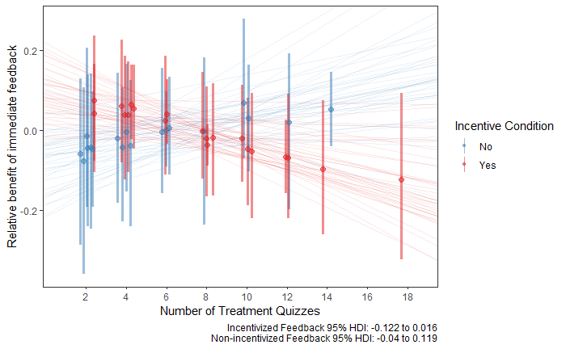

```r
p <- plot.class.level.moderator('Class_NumberOfTreatmentQuizzes', "Number of Treatment Quizzes", jitter=0.5)
p <- p + scale_x_continuous(breaks = seq(2,20,by=2))
ggsave('figs/moderators/class/Class_NumberOfTreatmentQuizzes.png', p, device="png", width=7, height=5)
p
```

#### Class Level: Cumulative Quiz Questions

Tallying the number of cumulative quiz questions

```r
classes.data %>% pull(Quiz_CumulativeNumberofQuizQuestions) %>% table()
```

```
.
  8  10  12  16  20  30  36  37  40  50  58  60  62  70  84  96 100 111 120 124 140 180 198
  1   1   4   1   2   2   1   1   6   1   1   1   1   1   1   1   3   1   3   1   2   1   1
```

Generating the plot

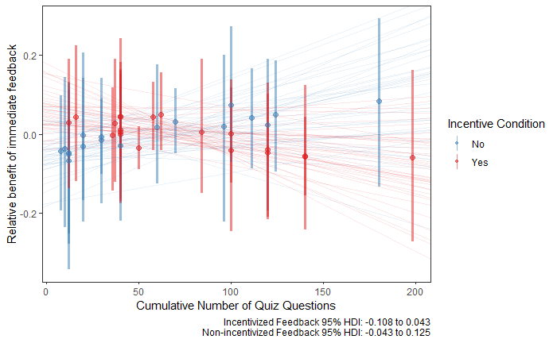

```r
plot.class.level.moderator('Quiz_CumulativeNumberofQuizQuestions', 'Cumulative Number of Quiz Questions', jitter=0)
```

Checking the correlation coefficient between number of questions and number of quizzes

```r
cor(classes.data$Quiz_CumulativeNumberofQuizQuestions, classes.data$Class_NumberOfTreatmentQuizzes, method="spearman")
```

```
[1] 0.7901743
```

#### Class Level: Length of Delay

Tallying the length of delay by classes

```r
classes.data %>% pull(Quiz_NumberOfDayDelay_BetweenDueDateandDelayedFeedback) %>% table()
```

```
.
 1  2  3  4  5
 7 11 14  3  3
```

Generating the plot

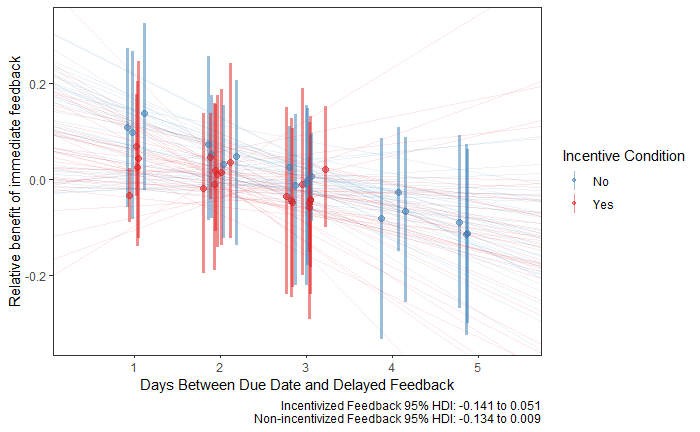

```r
plot.class.level.moderator('Quiz_NumberOfDayDelay_BetweenDueDateandDelayedFeedback', 'Days Between Due Date and Delayed Feedback', jitter=0.25)
```

#### Class Level: Proportion of Retrieval Based Exam Items

Generating the plot

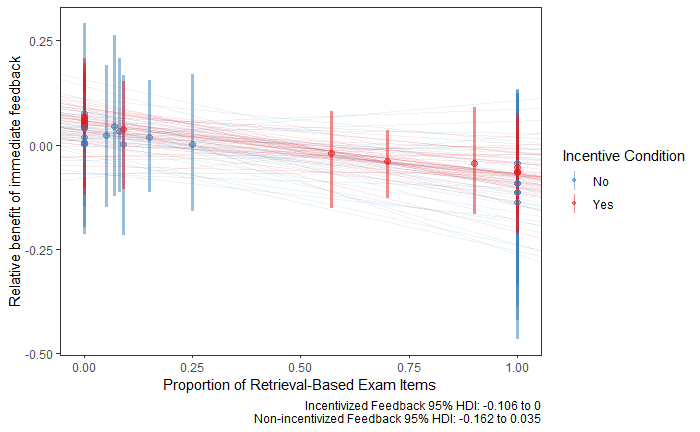

```r
plot.class.level.moderator('Exam_ProportionOfRetrievalBasedExamItems', 'Proportion of Retrieval-Based Exam Items', jitter=0)
```

Exploratory question (of a sort): What happens when we average parameter estimates across conditions?

```r
exam.retrieval.moderator.data <- readRDS('data/model-runs/moderator-class-Exam_ProportionOfRetrievalBasedExamItems.rds')

exam.retrival.moderator.data.tidy <- exam.retrieval.moderator.data %>%
  spread_draws(moderator.effect[incentive]) %>%
  group_by(.chain, .iteration, .draw) %>%
  summarize(m.effect = mean(moderator.effect)) %>%
  ungroup() %>%
  median_hdci()
exam.retrival.moderator.data.tidy
```

| m.effect | .lower | .upper | .width | .point | .interval |
| --- | --- | --- | --- | --- | --- |
| -0.05560009 | -0.1134986 | -0.001660727 | 0.95 | median | hdci |

## Chain Info

Summarizing the chain diagnostics for moderators

```r
moderator.chain.summaries <- read_csv('data/generated/moderator-chain-summaries.csv')
```

```r
table(moderator.chain.summaries$n.samples.per.chain)
```

```
 3000  9000 81000
   40     4     1
```

```r
min(moderator.chain.summaries$min.ess)
```

```
[1] 10000
```

```r
max(moderator.chain.summaries$worst.psrf)
```

```
[1] 1.004454
```